# Identify Quality of Weight Lifting Exercise

Machine Learning Course Project

Roberto Bonifacio

December 11, 2016

## Background

Using devices such as Jawbone Up, Nike FuelBand, and Fitbit it is now possible to collect a large amount of data about personal activity relatively inexpensively. These type of devices are part of the quantified self movement - a group of enthusiasts who take measurements about themselves regularly to improve their health, to find patterns in their behavior, or because they are tech geeks. One thing that people regularly do is quantify how much of a particular activity they do, but they rarely quantify how well they do it. In this project, your goal will be to use data from accelerometers on the belt, forearm, arm, and dumbell of 6 participants. They were asked to perform barbell lifts correctly and incorrectly in 5 different ways. More information is available from the website here: http://groupware.les.inf.puc-rio.br/har (see the section on the Weight Lifting Exercise Dataset).

Participants were asked to perform one set of 10 repetitions of the Unilateral Dumbbell Biceps Curl in five different fashions: exactly according to the specification (Class A), throwing the elbows to the front (Class B), lifting the dumbbell only halfway (Class C), lowering the dumbbell only halfway (Class D) and throwing the hips to the front (Class E). Class A corresponds to the specified execution of the exercise, while the other 4 classes correspond to common mistakes. What you should submit

## Purpose of this project

The goal of your project is to predict the manner in which they did the exercise. This is the “classe” variable in the training set. You may use any of the other variables to predict with. You should create a report describing how you built your model, how you used cross validation, what you think the expected out of sample error is, and why you made the choices you did. You will also use your prediction model to predict 20 different test cases.

## Analysis

The following steps were performed to create a machine learning model for the Weight Lifting Exercise Dataset Files were downloaded from site and each data set was verified for accuracy.

A Near Zero Variable function was performed to eliminate variables with a low frequency ratio.

Some variables had empty values or NA values so they were removed from the dataset. Multiple variables were plotted against the outcome classe to determine if there was a strong correlation between them.

### Data Slicing and Cross Validation

The training was splitted into two datasets, 75% of the data for sub-training and the rest 25% for validation. The purpose of this cross-validation was fit multiptle models on the sub-training dataset and to perform the tests on the validation dataset.

After selecting random forest using caret package, applied the model to test dataset and packaged the results in a file.

### Download the datasets

```r
setwd("C:/Users/rboni/practicalmachinelearning")
pmlTrainFile <- "./pml-training.csv"
pmlTestFile <- "./pml-testing.csv"
if (!file.exists(pmlTrainFile)){
    fileURL <- "https://d396qusza40orc.cloudfront.net/predmachlearn/pml-training.csv"
    download.file(fileURL, pmlTrainFile, mode="wb")
}
if (!file.exists(pmlTestFile)){
     fileURL <- "https://d396qusza40orc.cloudfront.net/predmachlearn/pml-testing.csv"
    download.file(fileURL, pmlTestFile, mode="wb")
}

if (file.exists(pmlTrainFile)) {
    training = read.csv(pmlTrainFile,na.strings=c("NA","#DIV/0!", ""))

}
if (file.exists(pmlTestFile)) {
      testing = read.csv(pmlTestFile,na.strings=c("NA","#DIV/0!", ""))
}
dim(training)
```

```
## [1] 19622   160
```

```r
dim(testing)
```

```
## [1]  20 160
```

### Exploratory Analysis and Data Slicing for Cross-Validation

```r
#summary(training)
nzvCols <- nearZeroVar (training,saveMetrics=TRUE)
#display near zero variables = TRUE
nzvCols[nzvCols$nzv == "TRUE",]
```

```
##                        freqRatio percentUnique zeroVar  nzv
## new_window              47.33005    0.01019264   FALSE TRUE
## kurtosis_yaw_belt        0.00000    0.00000000    TRUE TRUE
## skewness_yaw_belt        0.00000    0.00000000    TRUE TRUE
## amplitude_yaw_belt       0.00000    0.00509632    TRUE TRUE
## avg_roll_arm            77.00000    1.68178575   FALSE TRUE
## stddev_roll_arm         77.00000    1.68178575   FALSE TRUE
## var_roll_arm            77.00000    1.68178575   FALSE TRUE
## avg_pitch_arm           77.00000    1.68178575   FALSE TRUE
## stddev_pitch_arm        77.00000    1.68178575   FALSE TRUE
## var_pitch_arm           77.00000    1.68178575   FALSE TRUE
## avg_yaw_arm             77.00000    1.68178575   FALSE TRUE
## stddev_yaw_arm          80.00000    1.66649679   FALSE TRUE
## var_yaw_arm             80.00000    1.66649679   FALSE TRUE
## max_roll_arm            25.66667    1.47793293   FALSE TRUE
## min_roll_arm            19.25000    1.41677709   FALSE TRUE
## min_pitch_arm           19.25000    1.47793293   FALSE TRUE
## amplitude_roll_arm      25.66667    1.55947406   FALSE TRUE
## amplitude_pitch_arm     20.00000    1.49831821   FALSE TRUE
## kurtosis_yaw_dumbbell    0.00000    0.00000000    TRUE TRUE
## skewness_yaw_dumbbell    0.00000    0.00000000    TRUE TRUE
## amplitude_yaw_dumbbell   0.00000    0.00509632    TRUE TRUE
## kurtosis_yaw_forearm     0.00000    0.00000000    TRUE TRUE
## skewness_yaw_forearm     0.00000    0.00000000    TRUE TRUE
## max_roll_forearm        27.66667    1.38110284   FALSE TRUE
## min_roll_forearm        27.66667    1.37091020   FALSE TRUE
## amplitude_roll_forearm  20.75000    1.49322189   FALSE TRUE
## amplitude_yaw_forearm    0.00000    0.00509632    TRUE TRUE
## avg_roll_forearm        27.66667    1.64101519   FALSE TRUE
## stddev_roll_forearm     87.00000    1.63082255   FALSE TRUE
## var_roll_forearm        87.00000    1.63082255   FALSE TRUE
## avg_pitch_forearm       83.00000    1.65120783   FALSE TRUE
## stddev_pitch_forearm    41.50000    1.64611151   FALSE TRUE
## var_pitch_forearm       83.00000    1.65120783   FALSE TRUE
## avg_yaw_forearm         83.00000    1.65120783   FALSE TRUE
## stddev_yaw_forearm      85.00000    1.64101519   FALSE TRUE
## var_yaw_forearm         85.00000    1.64101519   FALSE TRUE
```

```r
#remove empty and calculated columns
subsetNames<-grepl("^kurtosis|^skewness|^amplitude|^min|^max|^new_window|^raw_timestamp|^var|^avg|^stddev",names(training))

table(subsetNames)
```

```
## subsetNames
## FALSE  TRUE
##    57   103
```

```r
training <- training[!subsetNames]
testing <- testing[!subsetNames]

dim(training)
```

```
## [1] 19622    57
```

```r
dim(testing)
```

```
## [1] 20 57
```

Here is a feature plot of some variables in relation to the outcome classe. Just to have a preliminary idea on how they related to each other.

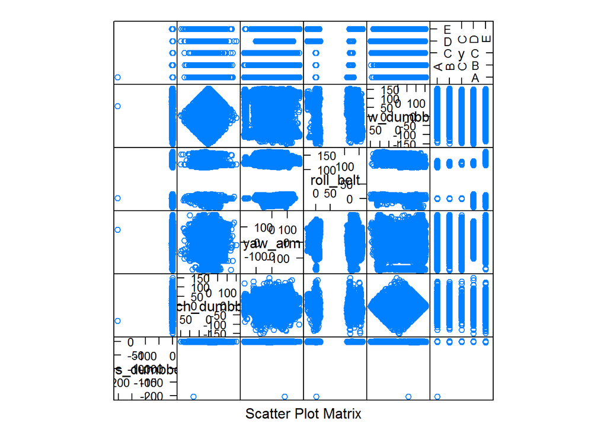

```r
featurePlot(x=training[c("gyros_dumbbell_x","pitch_dumbbell","yaw_arm","roll_belt","yaw_dumbbell")],y=as.character(training$classe),plot="pairs")
```

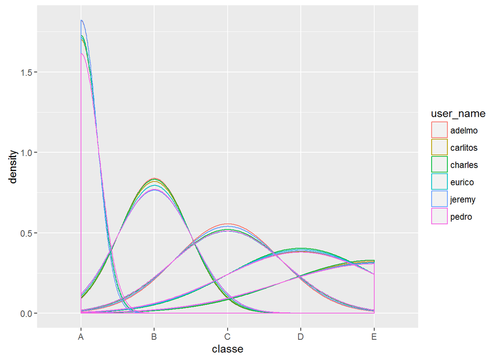

```r
#density plot
qplot(classe,colour=user_name,data=training,geom="density")
```

```r
set.seed(2345)
inBuild <- createDataPartition(y=training$classe, p=0.75, list=FALSE)
validation <- training[-inBuild,]
training <- training[inBuild,]

#remove user_name and timestamp which are not needed for prediction
subsetNames2<-grepl("^X|^num_window|^user_name|^cvtd_timestamp",names(training))
training <- training[!subsetNames2]
validation <- validation[!subsetNames2]
#subTest <- subTest[!subsetNames2]
testing <- testing[!subsetNames2]

dim(training)
```

```
## [1] 14718    53
```

```r
dim(validation)
```

```
## [1] 4904   53
```

```r
dim(testing)
```

```
## [1] 20 53
```

```r
table(training$classe)
```

```
##
##    A    B    C    D    E
## 4185 2848 2567 2412 2706
```

Please note other models were fitted as well but were not suitable to process this type of data.

```r
set.seed(2345)
#fit random forest model
modFit.rf <- train(classe ~ .,data=training,method="rf")
#fit decission trees model
#modFit.rp <- train(classe ~ ., method="rpart", data=training,trControl=trainControl(method="cv",number=3))
#fit boosting model
#modFit.bt <- train(classe ~.,data=training,method="gbm",verbose=FALSE)

#evaluate predictions against validation dataset
predVal.rf <- predict(modFit.rf,validation)
#predVal.bt <- predict(modFit.bt,validation)
#predVal.rp <- predict(modFit.rp,validation)

#obtain confusion matrix
cm.rf <- confusionMatrix(predVal.rf, validation$classe)
#cm.bt <- confusionMatrix(predVal.bt, validation$classe)
#cm.rp <- confusionMatrix(predVal.rp, validation$classe)

cm.rf$overall['Accuracy']
```

```
## Accuracy
## 0.992863
```

```r
#cm.rp$overall['Accuracy']
#cm.bt$overall['Accuracy']

#calculate RMSE
sqrt(sum((as.integer(predVal.rf) -as.integer(validation$classe))^2))
```

```
## [1] 5.91608
```

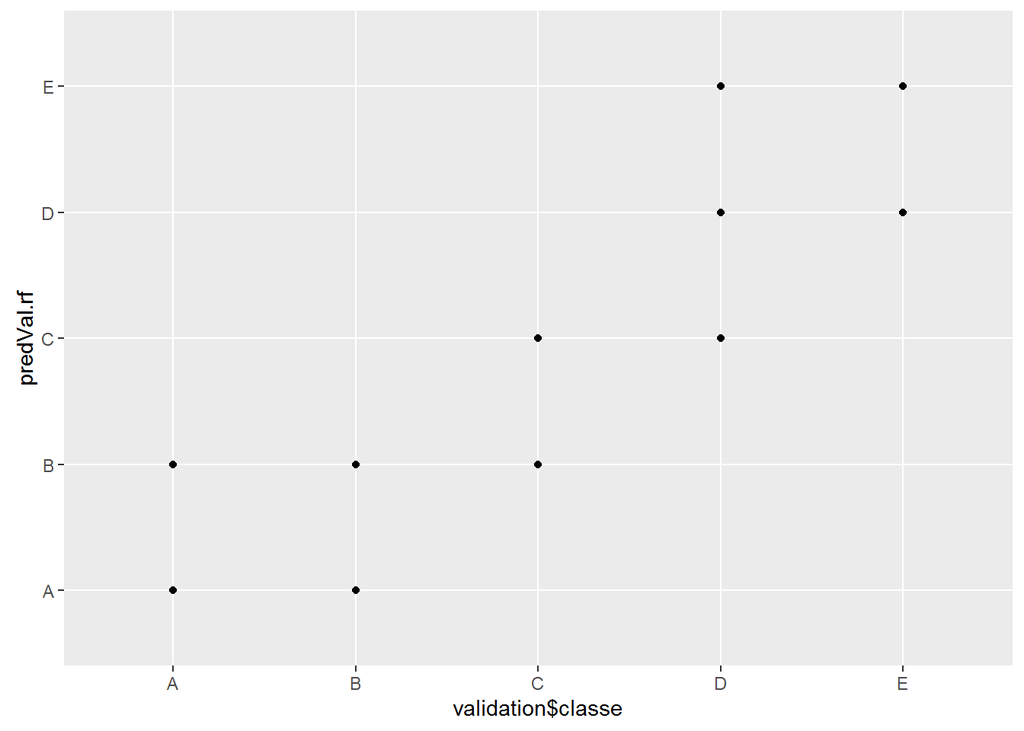

```r
#sqrt(sum((as.integer(predVal.rp) -as.integer(validation$classe))^2))
#sqrt(sum((as.integer(predVal.bt) -as.integer(validation$classe))^2))

#plot predicted values against values in validation subset
qplot(validation$classe,predVal.rf)
```

```r
#qplot(validation$classe,predVal.rp)
#qplot(validation$classe,predVal.bt)
```

### Conclusion

Here is the prediction values for the testing dataset based on the selected model.

### Use final model to predict outcome classe from testing dataset.

```r
# picked teh RF model as it is the most accurate and has less errors
predTest.rf <- predict(modFit.rf, testing)
predTest.rf
```

```
##  [1] B A B A A E D B A A B C B A E E A B B B
## Levels: A B C D E
```